# DS202A - W04 Summative

Author

32490

### Setup

```r
library(dplyr)
library(tidyr)
library(readr)
library(lubridate)
library(tidyselect)
library(tidyverse)
library(tidymodels)
```

```r
uk_hpi=read_csv("UK-HPI-full-file-2023-06.csv")
```

### Creating the main dataset

```r
df_uk<-
    uk_hpi %>%
    select("RegionName", "SalesVolume", "Date", "FlatPrice") %>%
    filter(RegionName == "United Kingdom")%>%
    arrange(Date) %>%
    mutate(SalesVolumelag1 = lag(SalesVolume, 1))%>%
    mutate(FlatPricelag1 = lag(FlatPrice))%>%
    drop_na(SalesVolumelag1)%>%
    drop_na(FlatPricelag1)%>%
    arrange(desc(Date))

df_uk  %>% head(8) %>% knitr::kable()
```

| RegionName | SalesVolume | Date | FlatPrice | SalesVolumelag1 | FlatPricelag1 |
| --- | --- | --- | --- | --- | --- |
| United Kingdom | 70248.00 | 01/12/2022 | 230935.0 | 81100.33 | 219287.8 |
| United Kingdom | 81100.33 | 01/12/2021 | 219287.8 | 104607.67 | 211424.4 |
| United Kingdom | 104607.67 | 01/12/2020 | 211424.4 | 84958.33 | 203611.2 |
| United Kingdom | 84958.33 | 01/12/2019 | 203611.2 | 83837.00 | 205193.5 |
| United Kingdom | 83837.00 | 01/12/2018 | 205193.5 | 91613.33 | 203173.5 |
| United Kingdom | 91613.33 | 01/12/2017 | 203173.5 | 94685.00 | 195783.7 |
| United Kingdom | 94685.00 | 01/12/2016 | 195783.7 | 94396.67 | 184535.4 |
| United Kingdom | 94396.67 | 01/12/2015 | 184535.4 | 88917.00 | 174054.3 |

```r
head(df_uk)
```

```
# A tibble: 6 × 6
  RegionName     SalesVolume Date       FlatPrice SalesVolumelag1 FlatPricelag1
  <chr>                <dbl> <chr>          <dbl>           <dbl>         <dbl>
1 United Kingdom      70248  01/12/2022   230935           81100.       219288.
2 United Kingdom      81100. 01/12/2021   219288.         104608.       211424.
3 United Kingdom     104608. 01/12/2020   211424.          84958.       203611.
4 United Kingdom      84958. 01/12/2019   203611.          83837        205194.
5 United Kingdom      83837  01/12/2018   205194.          91613.       203174.
6 United Kingdom      91613. 01/12/2017   203174.          94685        195784.
```

I retroactively added the variable FlatPrice to the df_uk dataset and lagged it, in order to build a second model.

In order to be able to make predictions, I have lagged variables, but it is important to note that this makes the assumption that future data relies on the relationship between current and previous data. It assumes that the predictor helps for forecasting future data, but if the future data doesn’t follow that same relationship, the predictions risk being inaccurate.

### Creating the training and testing data sets

```r
df_uk_train<-
  df_uk%>%
  filter(mdy(Date) < mdy("01/12/2019"))

df_uk_train
```

```
# A tibble: 176 × 6
   RegionName     SalesVolume Date       FlatPrice SalesVolumelag1 FlatPricelag1
   <chr>                <dbl> <chr>          <dbl>           <dbl>         <dbl>
 1 United Kingdom      83837  01/12/2018   205194.          91613.       203174.
 2 United Kingdom      91613. 01/12/2017   203174.          94685        195784.
 3 United Kingdom      94685  01/12/2016   195784.          94397.       184535.
 4 United Kingdom      94397. 01/12/2015   184535.          88917        174054.
 5 United Kingdom      88917  01/12/2014   174054.          90540        158479.
 6 United Kingdom      90540  01/12/2013   158479.          63795        146086.
 7 United Kingdom      63795  01/12/2012   146086.          70770        144095.
 8 United Kingdom      70770  01/12/2011   144095.          63541.       143845.
 9 United Kingdom      63541. 01/12/2010   143845.          87202        144066.
10 United Kingdom      87202  01/12/2009   144066.          46373.       140291.
# ℹ 166 more rows
```

```r
df_uk_test<-
  df_uk%>%
  filter(mdy(Date) >= mdy("01/01/2020"))

df_uk_test
```

```
# A tibble: 42 × 6
   RegionName     SalesVolume Date       FlatPrice SalesVolumelag1 FlatPricelag1
   <chr>                <dbl> <chr>          <dbl>           <dbl>         <dbl>
 1 United Kingdom      70248  01/12/2022   230935           81100.       219288.
 2 United Kingdom      81100. 01/12/2021   219288.         104608.       211424.
 3 United Kingdom     104608. 01/12/2020   211424.          84958.       203611.
 4 United Kingdom      80197  01/11/2022   233054           76313.       220260.
 5 United Kingdom      76313. 01/11/2021   220260.          96254.       211188.
 6 United Kingdom      96254. 01/11/2020   211188.          93439.       202398.
 7 United Kingdom      79740  01/10/2022   231949           64254.       216574.
 8 United Kingdom      64254. 01/10/2021   216574.          97907.       208547.
 9 United Kingdom      97907. 01/10/2020   208547.          90625.       204632.
10 United Kingdom      83404  01/09/2022   233037          129270.       222368.
# ℹ 32 more rows
```

### Model 1: sales volume

```r
lin_model <-
    linear_reg() %>%
    set_engine("lm") %>%
    fit(SalesVolume ~ SalesVolumelag1, data = df_uk_train)
```

```r
lin_model %>% tidy()
```

```
# A tibble: 2 × 5
  term             estimate std.error statistic  p.value
  <chr>               <dbl>     <dbl>     <dbl>    <dbl>
1 (Intercept)     33726.    5208.          6.48 1.04e- 9
2 SalesVolumelag1     0.578    0.0600      9.63 1.07e-17
```

The lagged sales volume data is used as a predictor for sales volume in a linear model, hence the variable name lin_model. This model gives an intercept of 33,725.63 and a slope of 0.5780873, indicating a moderate slope.

```r
summary(lin_model$fit)
```

```
Call:
stats::lm(formula = SalesVolume ~ SalesVolumelag1, data = data)

Residuals:
   Min     1Q Median     3Q    Max
-59818  -8777    576  10639  59499

Coefficients:
                 Estimate Std. Error t value Pr(>|t|)
(Intercept)     3.373e+04  5.208e+03   6.475 1.04e-09 ***
SalesVolumelag1 5.781e-01  6.002e-02   9.631  < 2e-16 ***
---
Signif. codes:  0 '***' 0.001 '**' 0.01 '*' 0.05 '.' 0.1 ' ' 1

Residual standard error: 19350 on 165 degrees of freedom
  (9 observations deleted due to missingness)
Multiple R-squared:  0.3599,    Adjusted R-squared:  0.356
F-statistic: 92.75 on 1 and 165 DF,  p-value: < 2.2e-16
```

Summarising the model’s fit shows its statistical significance, which is evidence that the lagged sales volume has an impact on sales volume.

```r
lin_model %>% augment(df_uk_train)
```

```
# A tibble: 176 × 8
    .pred  .resid RegionName     SalesVolume Date      FlatPrice SalesVolumelag1
    <dbl>   <dbl> <chr>                <dbl> <chr>         <dbl>           <dbl>
 1 86686.  -2849. United Kingdom      83837  01/12/20…   205194.          91613.
 2 88462.   3152. United Kingdom      91613. 01/12/20…   203174.          94685
 3 88295.   6390. United Kingdom      94685  01/12/20…   195784.          94397.
 4 85127.   9269. United Kingdom      94397. 01/12/20…   184535.          88917
 5 86066.   2851. United Kingdom      88917  01/12/20…   174054.          90540
 6 70605.  19935. United Kingdom      90540  01/12/20…   158479.          63795
 7 74637. -10842. United Kingdom      63795  01/12/20…   146086.          70770
 8 70458.    312. United Kingdom      70770  01/12/20…   144095.          63541.
 9 84136. -20595. United Kingdom      63541. 01/12/20…   143845.          87202
10 60533.  26669. United Kingdom      87202  01/12/20…   144066.          46373.
# ℹ 166 more rows
# ℹ 1 more variable: FlatPricelag1 <dbl>
```

This table shows very high residuals, probably due to the fact that the values of sale volume are very high for the United Kingdom. The differences are therefore also very high.

#### The first model’s fit

```r
aug_lin_model <- lin_model %>% augment(df_uk_train)
```

This fits the a model to the training dataset and adds columns containing the predicted values and residuals for each row.

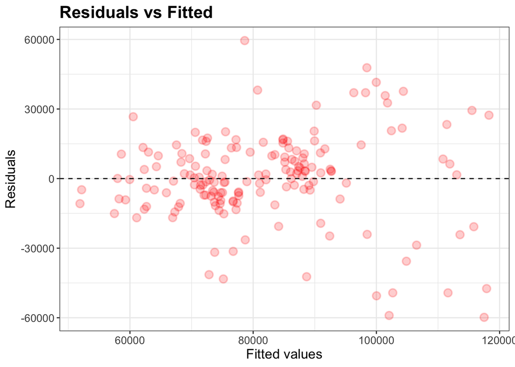

```r
plot_df_uk_train <- lin_model %>% augment(df_uk_train)
g_train <- ggplot(plot_df_uk_train, aes(x = .pred, y = .resid)) +
    geom_point(alpha=0.2, size=3, color="red", stroke=1) +
    geom_hline(yintercept = 0, linetype = "dashed") +
    labs(x = "Fitted values", y = "Residuals", title="Residuals vs Fitted") +
    theme_bw() +
    theme(axis.title.x = element_text(size = rel(1.2)),
          axis.text.x = element_text(size = rel(1.2)),
          axis.title.y = element_text(size = rel(1.2)),
          axis.text.y = element_text(size = rel(1.2)),
          plot.title = element_text(size = rel(1.5), face = "bold"))
g_train
```

Plotting the relationship between the fitted values and residuals shows no clear pattern to the scatter of points: this is a good sign for the model’s fit.

```r
mae_train <-
    lin_model%>%
    augment(df_uk_train) %>%
    mae(truth = SalesVolume, estimate = .pred)
mae_train
```

```
# A tibble: 1 × 3
  .metric .estimator .estimate
  <chr>   <chr>          <dbl>
1 mae     standard      13771.
```

Next, this calculates the mean absolute error for the training set. The model is on average off from the training data by 13771.43 units. This is a very large number but the sales volume data for the entire United Kingdom is much larger than for the individual regions: it is probably the sum of the sales volume data of each region. The residuals for very large predicted numbers are very large, in accordance.

Using base R functions, I’ll obtain diagnostic plots.

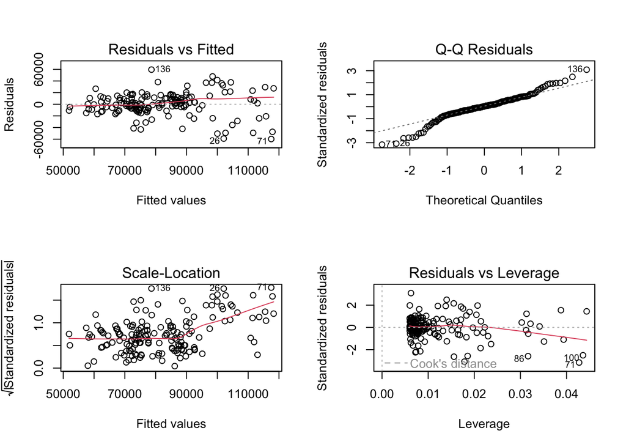

```r
base_r_model <- lm(SalesVolume ~ SalesVolumelag1, data = df_uk_train)
par(mfrow = c(2, 2))
plot(base_r_model)
```

These shows the relationship is not totally linear, but there is a more or less straight line in the Q-Q plot, showing that the residuals are approximately normally distributed.

#### Testing the first model

I’ll now use the model to predict the sales volume, based on the lagged sales volume, on the testing dataset. There’s no need to train a new model, because df_uk_test has the same variables as the ones the model was trained on, in df_uk_train.

First, I augment the testing set to obtain the model’s prediction for it, and then I calculate the MAE.

```r
lin_model %>%
    augment(df_uk_test) %>%
    mae(truth = SalesVolume, estimate = .pred)
```

```
# A tibble: 1 × 3
  .metric .estimator .estimate
  <chr>   <chr>          <dbl>
1 mae     standard      22682.
```

The error is quite a bit higher than for the training dataset. This may be because the model is not taking enough predicting factors into account, and is therefore not capturing the changes that occur between the training and testing datasets.

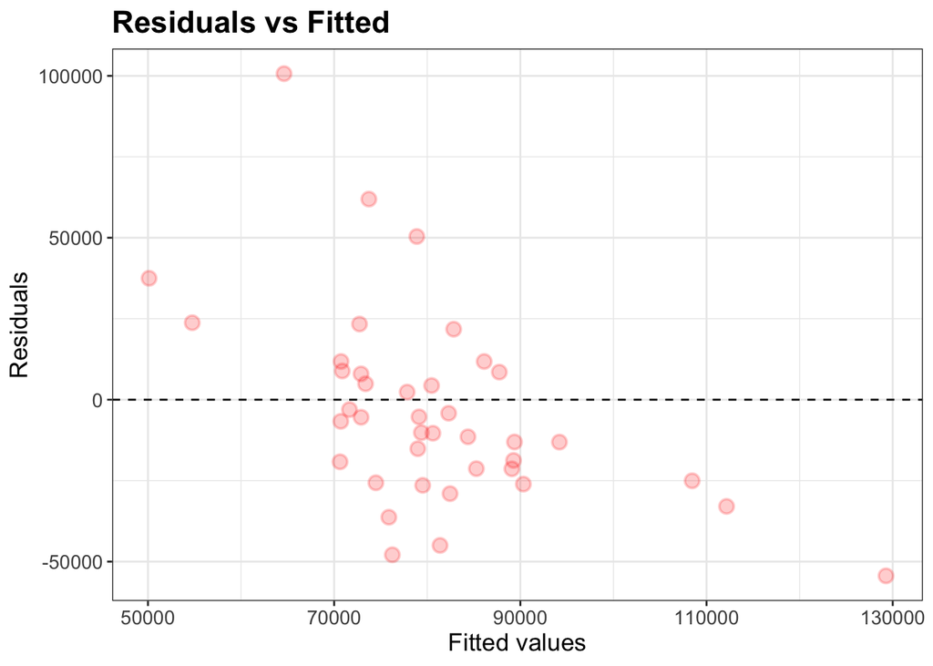

```r
plot_df_uk_test <- lin_model %>% augment(df_uk_test)
g_test <- ggplot(plot_df_uk_test, aes(x = .pred, y = .resid)) +
    geom_point(alpha=0.2, size=3, color="red", stroke=1) +
    geom_hline(yintercept = 0, linetype = "dashed") +
    labs(x = "Fitted values", y = "Residuals", title="Residuals vs Fitted") +
    theme_bw() +
    theme(axis.title.x = element_text(size = rel(1.2)),
          axis.text.x = element_text(size = rel(1.2)),
          axis.title.y = element_text(size = rel(1.2)),
          axis.text.y = element_text(size = rel(1.2)),
          plot.title = element_text(size = rel(1.5), face = "bold"))
g_test
```

Running a scatter plot of the residuals shows that this isn’t such a great fit since there does seem to be a pattern to the scatter.

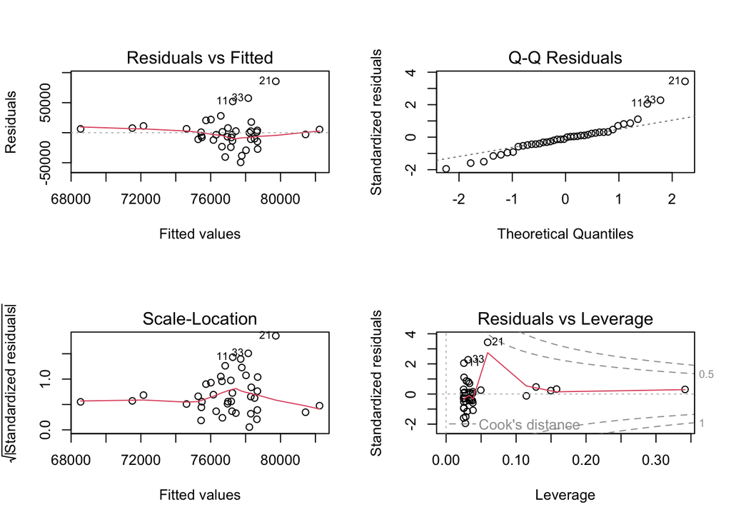

```r
base_r_test_model <- lm(SalesVolume ~ SalesVolumelag1, data = df_uk_test)
par(mfrow = c(2, 2))
plot(base_r_test_model)
```

The Scale-Location and Residuals vs Leverage lines are far from straight, indicating further that this model isn’t such a good fit. I can try using more predictors to see if the model becomes more suited.

### Model 2: flat price

It is reasonable to assuem that flat price changes are likely to affect sales, so let’s add FlatPriceslag1 to the model and call it lin_model_2. However, as I have had to delete rows containing missing values for flat prices, it is possible that this addition restricts the amount of data that is avaible to train the model.

```r
lin_model_2 <-
    linear_reg() %>%
    set_engine("lm") %>%
    fit(SalesVolume ~ SalesVolumelag1 + FlatPricelag1, data = df_uk_train)
```

```r
summary(lin_model_2$fit)
```

```
Call:
stats::lm(formula = SalesVolume ~ SalesVolumelag1 + FlatPricelag1,
    data = data)

Residuals:
   Min     1Q Median     3Q    Max
-60951  -9336    603  11266  61020

Coefficients:
                  Estimate Std. Error t value Pr(>|t|)
(Intercept)      5.179e+04  1.090e+04   4.753 4.36e-06 ***
SalesVolumelag1  5.994e-01  6.063e-02   9.886  < 2e-16 ***
FlatPricelag1   -1.229e-01  6.527e-02  -1.883   0.0615 .
---
Signif. codes:  0 '***' 0.001 '**' 0.01 '*' 0.05 '.' 0.1 ' ' 1

Residual standard error: 19200 on 164 degrees of freedom
  (9 observations deleted due to missingness)
Multiple R-squared:  0.3734,    Adjusted R-squared:  0.3658
F-statistic: 48.87 on 2 and 164 DF,  p-value: < 2.2e-16
```

```r
aug_lin_model_2 <- lin_model_2 %>% augment(df_uk_train)
```

Here, the model is used to make predictions on the training dataset. The mean absolute error is then calculated:

```r
mae_train_2 <-
    lin_model_2%>%
    augment(df_uk_train) %>%
    mae(truth = SalesVolume, estimate = .pred)
mae_train_2
```

```
# A tibble: 1 × 3
  .metric .estimator .estimate
  <chr>   <chr>          <dbl>
1 mae     standard      13936.
```

The model is on average off from the training data by 13935.6 units.

#### Testing model 2

```r
lin_model_2 %>%
    augment(df_uk_test) %>%
    mae(truth = SalesVolume, estimate = .pred)
```

```
# A tibble: 1 × 3
  .metric .estimator .estimate
  <chr>   <chr>          <dbl>
1 mae     standard      21379.
```

The error is higher here than for the training dataset. Maybe past flat price changes don’t explain much variance in sales volume either, or maybe this model is overfitting, because it is too aligned to the training dataset.

However, this second model is a little bit lower than for the previous model’s prediction (22682.29-21379.47=1302.82). Therefore, the second model is to be preferred slightly better as it gives very slightly more accurate predictions.

### Use of AI

I used ChatGPT in order to understand several ways to visually determine a linear model’s fit (namely, through the Q-Q plot and through the absence of patterns in the plot of residuals).

I also used ChatGPT to verify the regular notation of the scientific lin_model tidy estimates.